# Slowdown hypothesis

### Life expectancy for best country (labelled by this country)

A similar approach to White (2002) is presented in [Christenson 2009](https://linkinghub.elsevier.com/retrieve/pii/S0140673609614604) Their approach is to look at life expectancy for the top performing country, rather than the average of these. Let’s now replicate this

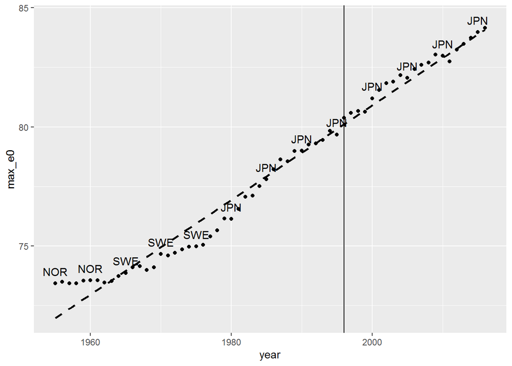

```r
tmp <- dta_e0 %>%
  filter(code %in% high_income_countries) %>%
  filter(sex == "total") %>%
  filter(between(year, 1955, 2016)) %>%
  group_by(year) %>%
  summarise(
    max_e0 = max(e0, na.rm = T),
    which_code = code[e0 == max(e0)]
    ) %>%
  ungroup()

tmp %>%
  ggplot(aes(x = year, y = max_e0)) +
  geom_point() +
  geom_text(
    aes(x = year, y = max_e0, label = which_code),
    inherit.aes = F,
    data = tmp %>% filter(year %in% seq(1955, 2015, by = 5)),
    nudge_y = 0.5

  ) +
  stat_smooth(method = "lm", se = F, colour = "black", linetype = "dashed") +
  geom_vline(xintercept = 1996)
```

Japan has remained the high income country with the highest life expectancy since the mid 1980s.

What’s the linear rate of improvement for the best performing line compared with the average improvement line?

```r
tmp %>%
  filter(between(year, 1955, 2016)) %>%
  lm(max_e0 ~ I(year - min(year)), .) %>%
  summary()
```

```
##
## Call:
## lm(formula = max_e0 ~ I(year - min(year)), data = .)
##
## Residuals:
##     Min      1Q  Median      3Q     Max
## -1.0889 -0.2810  0.0390  0.2938  1.4592
##
## Coefficients:
##                      Estimate Std. Error t value Pr(>|t|)
## (Intercept)         71.970799   0.132754  542.14   <2e-16 ***
## I(year - min(year))  0.198483   0.003754   52.87   <2e-16 ***
## ---
## Signif. codes:  0 '***' 0.001 '**' 0.01 '*' 0.05 '.' 0.1 ' ' 1
##
## Residual standard error: 0.529 on 60 degrees of freedom
## Multiple R-squared:  0.979,  Adjusted R-squared:  0.9786
## F-statistic:  2795 on 1 and 60 DF,  p-value: < 2.2e-16
```

Let’s now plot the mean, upper and lower together.

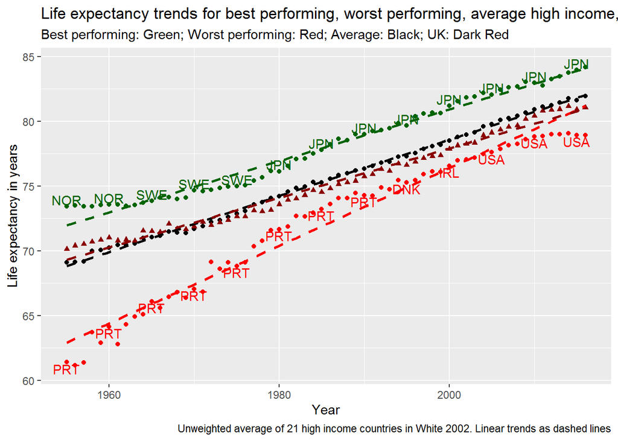

```r
tmp <- dta_e0 %>%
  filter(code %in% high_income_countries) %>%
  filter(sex == "total") %>%
  filter(between(year, 1955, 2016)) %>%
  group_by(year) %>%
  summarise(
    max_e0 = max(e0, na.rm = T),
    which_code_max = code[e0 == max(e0)],
    min_e0 = min(e0, na.rm = T),
    which_code_min = code[e0 == min(e0)],
    mean_e0 = mean(e0, na.rm = T),
    uk_e0 = e0[code == "GBR_NP"]
    ) %>%
  ungroup()

tmp %>%
  ggplot(aes(x = year)) +
  geom_point(aes(y = max_e0), colour = "darkgreen") +
  geom_text(
    aes(x = year, y = max_e0, label = which_code_max),
    inherit.aes = F,
    colour = "darkgreen",
    data = tmp %>% filter(year %in% seq(1955, 2015, by = 5)),
    nudge_y = 0.5
  ) +
  geom_point(aes(y = mean_e0)) +
  geom_point(aes(y = min_e0), colour = "red") +
  geom_point(aes(y = uk_e0), colour = "darkred", shape = 17) +
  geom_text(
    aes(x = year, y = min_e0, label = which_code_min),
    inherit.aes = F,
    colour = "red",
    data = tmp %>% filter(year %in% seq(1955, 2015, by = 5)),
    nudge_y = - 0.5
  ) +
  stat_smooth(aes(y = max_e0), method = "lm", se = F, colour = "darkgreen", linetype = "dashed") +
  stat_smooth(aes(y = min_e0), method = "lm", se = F, colour = "red", linetype = "dashed") +
  stat_smooth(aes(y = mean_e0), method = "lm", se = F, colour = "black", linetype = "dashed") +
  stat_smooth(aes(y = uk_e0), method = "lm", se = F, colour = "darkred", linetype = "dashed") +
  labs(
    x = "Year", y = "Life expectancy in years",
    title = "Life expectancy trends for best performing, worst performing, average high income, and UK, 1955-2016",
    subtitle = "Best performing: Green; Worst performing: Red; Average: Black; UK: Dark Red",
    caption = "Unweighted average of 21 high income countries in White 2002. Linear trends as dashed lines"
  )
```

```r
ggsave(here("figures", "pt1_sandwich.png"), height = 12, width = 20, units = "cm", dpi = 300)
ggsave(here("figures", "e0_limits", "fig_1_c_sandwich.png"), height = 12, width = 20, units = "cm", dpi = 300)
```

Table summarising above

- Intercept: $e_0$ in 1955
- Slope: Average $e_0$ gain per year since
- Fit: $R^2$

For worst, best, mean

```r
summary_best_worst_mean_hi <-
  dta_e0 %>%
    filter(code %in% high_income_countries) %>%
    filter(sex == "total") %>%
    filter(between(year, 1955, 2016)) %>%
    group_by(year) %>%
    summarise(
      max_e0 = max(e0, na.rm = T),
      which_code_max = code[e0 == max(e0)],
      min_e0 = min(e0, na.rm = T),
      which_code_min = code[e0 == min(e0)],
      mean_e0 = mean(e0, na.rm = T),
      uk_e0 = e0[code == "GBR_NP"]
      ) %>%
    ungroup() %>%
    select(year, min_e0, max_e0, mean_e0) %>%
    gather(-year, key = "popn", value = "e0") %>%
    group_by(popn) %>%
    nest() %>%
    mutate(model = map(data, ~lm(e0 ~ year, data = .))) %>%
    mutate(mdl_tidy = map(model, broom::tidy)) %>%
    mutate(mdl_diag = map(model, broom::glance))
```

```r
pt1 <-
  summary_best_worst_mean_hi %>%
    select(popn, mdl_tidy) %>%
    unnest(mdl_tidy) %>%
    filter(term == "year")

pt2 <-
  summary_best_worst_mean_hi %>%
      select(popn, mdl_diag) %>%
      unnest(mdl_diag) %>%
    select(popn, r.squared, adj.r.squared)

pt3 <-
  dta_e0 %>%
    filter(code %in% high_income_countries) %>%
    filter(sex == "total") %>%
    filter(between(year, 1955, 2016)) %>%
    group_by(year) %>%
    summarise(
      max_e0 = max(e0, na.rm = T),
      which_code_max = code[e0 == max(e0)],
      min_e0 = min(e0, na.rm = T),
      which_code_min = code[e0 == min(e0)],
      mean_e0 = mean(e0, na.rm = T),
      uk_e0 = e0[code == "GBR_NP"]
      ) %>%
    ungroup() %>%
    select(year, min_e0, max_e0, mean_e0) %>%
    filter(year == 1955) %>%
    gather(-year, key = "popn", value = "e0_1955") %>%
    select(-year)

pt1 %>% left_join(pt2) %>% left_join(pt3) %>%
  select(-term) %>%
  ungroup() %>%
  mutate(popn = case_when(
    popn == "min_e0"  ~ "Lowest",
    popn == "max_e0"  ~ "Highest",
    popn == "mean_e0"  ~ "Average",
    TRUE ~ NA_character_
  )) %>%
  rename(slope = estimate) %>%
  select(popn, e0_1955, slope, everything(), -p.value) %>%
  kable(digits = 3,
        col.names = c("Population", "e0 in 1955", "Average annual gain", "SE", "t value", "R squared", "Adj. R Squared")) %>%
  kable_styling()
```

| Population | e0 in 1955 | Average annual gain | SE | t value | R squared | Adj. R Squared |
| --- | --- | --- | --- | --- | --- | --- |
| Lowest | 61.400 | 0.299 | 0.007 | 41.250 | 0.966 | 0.965 |
| Highest | 73.430 | 0.198 | 0.004 | 52.871 | 0.979 | 0.979 |
| Average | 69.094 | 0.216 | 0.001 | 152.118 | 0.997 | 0.997 |

Life expectancy for all countries

```r
summary_best_worst_mean_hi <-
  dta_e0 %>%
    filter(code %in% all_distinct_countries) %>%
    filter(sex == "total") %>%
    filter(between(year, 1955, 2016)) %>%
    group_by(year) %>%
    summarise(
      max_e0 = max(e0, na.rm = T),
      which_code_max = code[e0 == max(e0)],
      min_e0 = min(e0, na.rm = T),
      which_code_min = code[e0 == min(e0)],
      mean_e0 = mean(e0, na.rm = T),
      uk_e0 = e0[code == "GBR_NP"]
      ) %>%
    ungroup() %>%
    select(year, min_e0, max_e0, mean_e0) %>%
    gather(-year, key = "popn", value = "e0") %>%
    group_by(popn) %>%
    nest() %>%
    mutate(model = map(data, ~lm(e0 ~ year, data = .))) %>%
    mutate(mdl_tidy = map(model, broom::tidy)) %>%
    mutate(mdl_diag = map(model, broom::glance))
```

```r
pt1 <-
  summary_best_worst_mean_hi %>%
    select(popn, mdl_tidy) %>%
    unnest(mdl_tidy) %>%
    filter(term == "year")

pt2 <-
  summary_best_worst_mean_hi %>%
      select(popn, mdl_diag) %>%
      unnest(mdl_diag) %>%
    select(popn, r.squared, adj.r.squared)

pt3 <-
  dta_e0 %>%
    filter(code %in% all_distinct_countries) %>%
    filter(sex == "total") %>%
    filter(between(year, 1955, 2016)) %>%
    group_by(year) %>%
    summarise(
      max_e0 = max(e0, na.rm = T),
      which_code_max = code[e0 == max(e0)],
      min_e0 = min(e0, na.rm = T),
      which_code_min = code[e0 == min(e0)],
      mean_e0 = mean(e0, na.rm = T),
      uk_e0 = e0[code == "GBR_NP"]
      ) %>%
    ungroup() %>%
    select(year, min_e0, max_e0, mean_e0) %>%
    filter(year == 1955) %>%
    gather(-year, key = "popn", value = "e0_1955") %>%
    select(-year)

pt1 %>% left_join(pt2) %>% left_join(pt3) %>%
  select(-term) %>%
  ungroup() %>%
  mutate(popn = case_when(
    popn == "min_e0"  ~ "Lowest",
    popn == "max_e0"  ~ "Highest",
    popn == "mean_e0"  ~ "Average",
    TRUE ~ NA_character_
  )) %>%
  rename(slope = estimate) %>%
  select(popn, e0_1955, slope, everything(), -p.value) %>%
  kable(digits = 3,
        col.names = c("Population", "e0 in 1955", "Average annual gain", "SE", "t value", "R squared", "Adj. R Squared")) %>%
  kable_styling()
```

| Population | e0 in 1955 | Average annual gain | SE | t value | R squared | Adj. R Squared |
| --- | --- | --- | --- | --- | --- | --- |
| Lowest | 61.400 | 0.083 | 0.015 | 5.340 | 0.322 | 0.311 |
| Highest | 73.430 | 0.196 | 0.003 | 58.461 | 0.983 | 0.982 |
| Average | 68.942 | 0.173 | 0.003 | 54.967 | 0.981 | 0.980 |

Let’s do the above, but for all countries

```r
all_countries_summary <-
  dta_e0 %>%
    filter(code %in% all_distinct_countries) %>%
    mutate(high_income = ifelse(code %in% high_income_countries, "High Income", "Other")) %>%
    filter(between(year, 1955, 2016)) %>%
    mutate(start_year = year - min(year)) %>%
    group_by(code, high_income, sex) %>%
    nest() %>%
    mutate(linmod = map(data, ~lm(e0 ~ start_year, data = .))) %>%
    mutate(
      tidied  = map(linmod, broom::tidy),
      glanced = map(linmod, broom::glance)
    ) %>%
    select(code, sex, high_income, tidied, glanced) %>%
    unnest(cols = c(tidied, glanced), names_sep = "_") %>%
    select(code, high_income, sex,
           term = tidied_term, estimate = tidied_estimate, SE = tidied_std.error, t_value = tidied_statistic,
           r_squared = glanced_r.squared, adj_r_squared = glanced_adj.r.squared
    ) %>%
    arrange(high_income, code, sex)


wb <- createWorkbook()
addWorksheet(wb, sheetName = "All Countries Summaries")
writeData(wb = wb, sheet = "All Countries Summaries", x = all_countries_summary)
openxlsx::saveWorkbook(wb, file = here("tables", "all_summaries.xlsx"), overwrite = TRUE)

all_countries_summary
```

| code | high_income | sex | term | estimate | SE | t_value | r_squared | adj_r_squared |
| --- | --- | --- | --- | --- | --- | --- | --- | --- |
| AUS | High Income | female | (Intercept) | 72.4503225806 | 0.121738346 | 595.1314839 | 0.9845554075 | 0.984297998 |
| AUS | High Income | female | start_year | 0.2129085140 | 0.003442592 | 61.8454109 | 0.9845554075 | 0.984297998 |
| AUS | High Income | male | (Intercept) | 65.2570967742 | 0.212044925 | 307.7512792 | 0.9677683771 | 0.967231183 |
| AUS | High Income | male | start_year | 0.2545108408 | 0.005996337 | 42.4443857 | 0.9677683771 | 0.967231183 |
| AUS | High Income | total | (Intercept) | 68.6866205837 | 0.159295267 | 431.1905933 | 0.9788304949 | 0.978477670 |
| AUS | High Income | total | start_year | 0.2372657450 | 0.004504650 | 52.6712977 | 0.9788304949 | 0.978477670 |
| AUT | High Income | female | (Intercept) | 70.5324731183 | 0.081616309 | 864.1958233 | 0.9939949494 | 0.993894865 |
| AUT | High Income | female | start_year | 0.2300088137 | 0.002307996 | 99.6573597 | 0.9939949494 | 0.993894865 |
| AUT | High Income | male | (Intercept) | 63.5273579109 | 0.159912017 | 397.2644394 | 0.9810750282 | 0.980759612 |
| AUT | High Income | male | start_year | 0.2522019088 | 0.004522091 | 55.7710878 | 0.9810750282 | 0.980759612 |

[output cut: 236 more lines]

```r
tmp %>%
  lm(max_e0 ~ I(year - min(year)), .) %>%
  summary()
```

```
##
## Call:
## lm(formula = max_e0 ~ I(year - min(year)), data = .)
##
## Residuals:
##     Min      1Q  Median      3Q     Max
## -1.0889 -0.2810  0.0390  0.2938  1.4592
##
## Coefficients:
##                      Estimate Std. Error t value Pr(>|t|)
## (Intercept)         71.970799   0.132754  542.14   <2e-16 ***
## I(year - min(year))  0.198483   0.003754   52.87   <2e-16 ***
## ---
## Signif. codes:  0 '***' 0.001 '**' 0.01 '*' 0.05 '.' 0.1 ' ' 1
##
## Residual standard error: 0.529 on 60 degrees of freedom
## Multiple R-squared:  0.979,  Adjusted R-squared:  0.9786
## F-statistic:  2795 on 1 and 60 DF,  p-value: < 2.2e-16
```

```r
tmp %>%
  lm(min_e0 ~ I(year - min(year)), .) %>%
  summary()
```

```
##
## Call:
## lm(formula = min_e0 ~ I(year - min(year)), data = .)
##
## Residuals:
##      Min       1Q   Median       3Q      Max
## -2.26750 -0.56342 -0.01802  0.84869  1.70461
##
## Coefficients:
##                     Estimate Std. Error t value Pr(>|t|)
## (Intercept)         62.90960    0.25673  245.04   <2e-16 ***
## I(year - min(year))  0.29947    0.00726   41.25   <2e-16 ***
## ---
## Signif. codes:  0 '***' 0.001 '**' 0.01 '*' 0.05 '.' 0.1 ' ' 1
##
## Residual standard error: 1.023 on 60 degrees of freedom
## Multiple R-squared:  0.9659, Adjusted R-squared:  0.9654
## F-statistic:  1702 on 1 and 60 DF,  p-value: < 2.2e-16
```

The average annual improvement for the best-performing country is 0.198 years/year, with an R-squared of 0.979.

For the worst-performing country, the average annual improvement is 0.299 years/year, indicating a tendency towards convergence. The R-squared is somewhat lower, at 0.966.

The USA has been the worst performing high income country since the early 2000s, and its life expectancy has fallen steadily below the long-term trend for worst-performing countries.

The UK’s life expectancy was that projected for the worst-performing country trend in 2015, and in 2016 fell below the linear projection for the worst performing country.

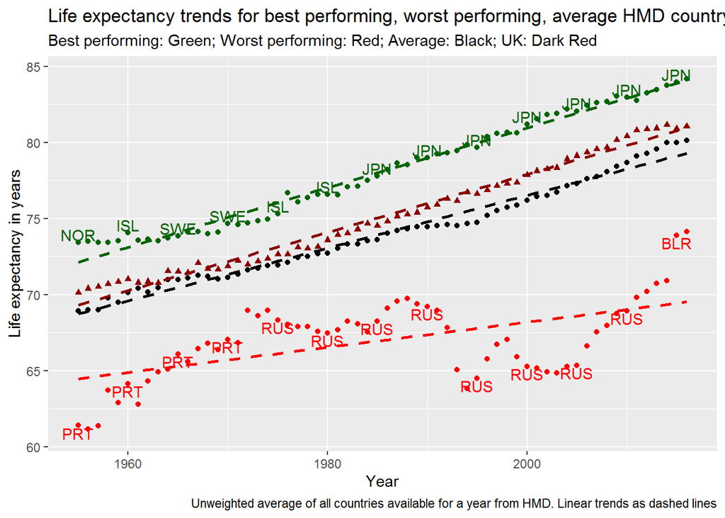

```r
tmp <- dta_e0 %>%
  filter(code %in% all_distinct_countries) %>%
  filter(sex == "total") %>%
  filter(between(year, 1955, 2016)) %>%
  group_by(year) %>%
  summarise(
    max_e0 = max(e0, na.rm = T),
    which_code_max = code[e0 == max(e0)],
    min_e0 = min(e0, na.rm = T),
    which_code_min = code[e0 == min(e0)],
    mean_e0 = mean(e0, na.rm = T),
    uk_e0 = e0[code == "GBR_NP"]
    ) %>%
  ungroup()

tmp %>%
  ggplot(aes(x = year)) +
  geom_point(aes(y = max_e0), colour = "darkgreen") +
  geom_text(
    aes(x = year, y = max_e0, label = which_code_max),
    inherit.aes = F,
    colour = "darkgreen",
    data = tmp %>% filter(year %in% seq(1955, 2015, by = 5)),
    nudge_y = 0.5
  ) +
  geom_point(aes(y = mean_e0)) +
  geom_point(aes(y = min_e0), colour = "red") +
  geom_point(aes(y = uk_e0), colour = "darkred", shape = 17) +
  geom_text(
    aes(x = year, y = min_e0, label = which_code_min),
    inherit.aes = F,
    colour = "red",
    data = tmp %>% filter(year %in% seq(1955, 2015, by = 5)),
    nudge_y = - 0.5
  ) +
  stat_smooth(aes(y = max_e0), method = "lm", se = F, colour = "darkgreen", linetype = "dashed") +
  stat_smooth(aes(y = min_e0), method = "lm", se = F, colour = "red", linetype = "dashed") +
  stat_smooth(aes(y = mean_e0), method = "lm", se = F, colour = "black", linetype = "dashed") +
  stat_smooth(aes(y = uk_e0), method = "lm", se = F, colour = "darkred", linetype = "dashed") +
  labs(
    x = "Year", y = "Life expectancy in years",
    title = "Life expectancy trends for best performing, worst performing, average HMD country, and UK, 1955-2016",
    subtitle = "Best performing: Green; Worst performing: Red; Average: Black; UK: Dark Red",
    caption = "Unweighted average of all countries available for a year from HMD. Linear trends as dashed lines"
  )
```

```r
ggsave("figures/e0_limits/appendix/fig_1_c_sandwich_all_hmd.png", height = 12, width = 20, units = "cm", dpi = 300)
```

Now Russia has been the worst performing country from the early 1970s. Belarus (?) appears to be for the last couple of years but this may be because the records from Russia aren’t available for these years, as indicated by the discontinuity.

## Figure 2

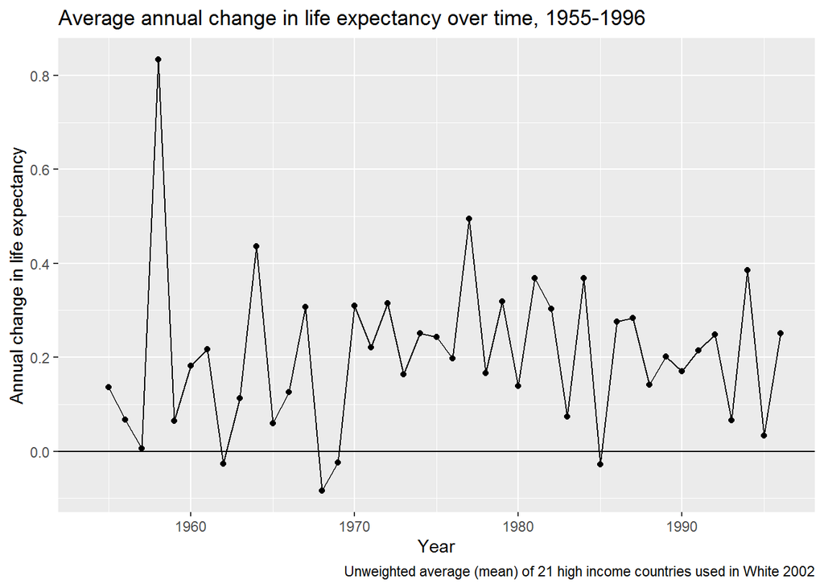

```r
fig_02_dta <- dta_e0 %>%
  filter(sex == "total") %>%
  filter(code %in% high_income_countries) %>%
  filter(between(year, 1954, 1996)) %>%
  group_by(year) %>%
  summarise(mean_e0 = mean(e0, na.rm = T)) %>%
  ungroup() %>%
  arrange(year) %>%
  mutate(ch_e0 = mean_e0 - lag(mean_e0))

fig_02_dta %>%
  ggplot(aes(x = year, y = ch_e0)) +
  geom_point() + geom_line() +
  geom_hline(yintercept = 0) +
  labs(x = "Year", y = "Annual change in life expectancy",
       title = "Average annual change in life expectancy over time, 1955-1996",
       caption = "Unweighted average (mean) of 21 high income countries used in White 2002")
```

And how about subsequent to this?

Without bars, then with bars

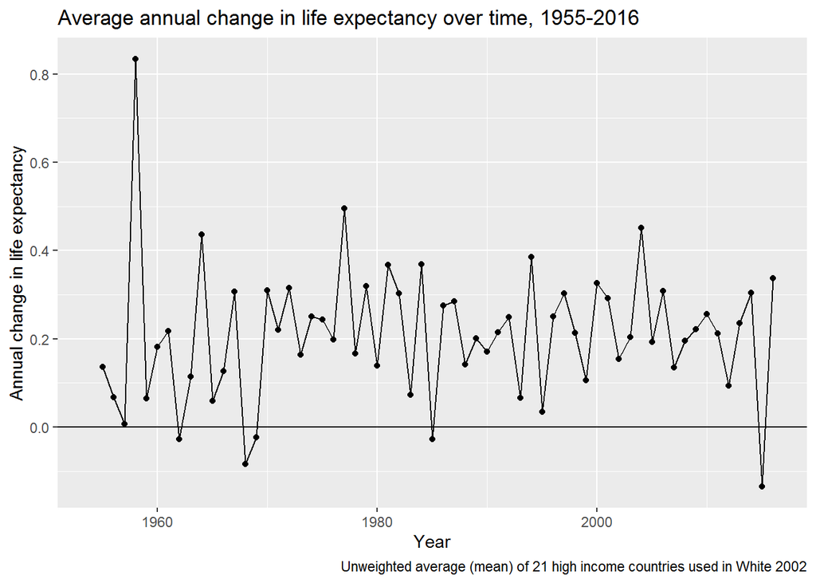

```r
tmp <- dta_e0 %>%
  filter(sex == "total") %>%
  filter(code %in% high_income_countries) %>%
  filter(between(year, 1954, 2016)) %>%
  group_by(year) %>%
  summarise(mean_e0 = mean(e0, na.rm = T)) %>%
  ungroup() %>%
  arrange(year) %>%
  mutate(ch_e0 = mean_e0 - lag(mean_e0))

fig_ch <- tmp %>%
  ggplot(aes(x = year, y = ch_e0)) +
  geom_point() + geom_line() +
  geom_hline(yintercept = 0) +
  labs(x = "Year", y = "Annual change in life expectancy",
       title = "Average annual change in life expectancy over time, 1955-2016",
       caption = "Unweighted average (mean) of 21 high income countries used in White 2002")

print(fig_ch)
```

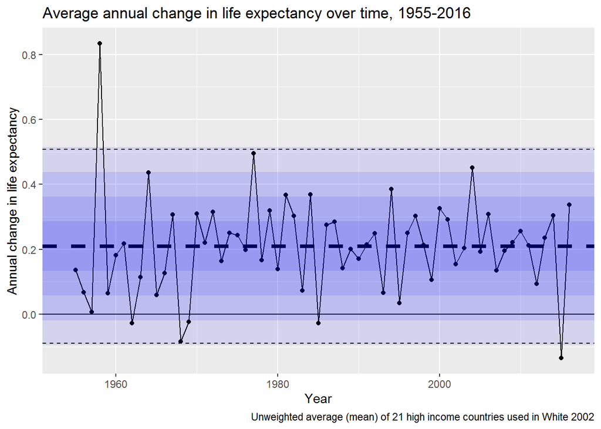

```r
ggsave("figures/supp_avg_ch_e0.png", height = 12, width = 29, units = "cm", dpi = 300)
fig_ch +
    geom_hline(aes(yintercept = mean(ch_e0, na.rm = TRUE)), size = 1.5, linetype = "dashed") +
  annotate(geom = "rect",
      xmin = -Inf, xmax = Inf,
      ymin = mean(tmp$ch_e0, na.rm = TRUE) - 0.5 * sd(tmp$ch_e0, na.rm = TRUE),
      ymax = mean(tmp$ch_e0, na.rm = TRUE) + 0.5 * sd(tmp$ch_e0, na.rm = TRUE),
    alpha = 0.1, fill = "blue"
  ) +
  annotate(geom = "rect",
      xmin = -Inf, xmax = Inf,
      ymin = mean(tmp$ch_e0, na.rm = TRUE) - 1.0 * sd(tmp$ch_e0, na.rm = TRUE),
      ymax = mean(tmp$ch_e0, na.rm = TRUE) + 1.0 * sd(tmp$ch_e0, na.rm = TRUE),
    alpha = 0.1, fill = "blue"
  ) +
  annotate(geom = "rect",
      xmin = -Inf, xmax = Inf,
      ymin = mean(tmp$ch_e0, na.rm = TRUE) - 1.5 * sd(tmp$ch_e0, na.rm = TRUE),
      ymax = mean(tmp$ch_e0, na.rm = TRUE) + 1.5 * sd(tmp$ch_e0, na.rm = TRUE),
    alpha = 0.1, fill = "blue"
  ) +
  annotate(geom = "rect",
      xmin = -Inf, xmax = Inf,
      ymin = mean(tmp$ch_e0, na.rm = TRUE) - 2.0 * sd(tmp$ch_e0, na.rm = TRUE),
      ymax = mean(tmp$ch_e0, na.rm = TRUE) + 2.0 * sd(tmp$ch_e0, na.rm = TRUE),
    alpha = 0.1, fill = "blue"
  ) +
  geom_hline(aes(yintercept = mean(ch_e0, na.rm = TRUE) - 1.96 * sd(ch_e0, na.rm = TRUE)), linetype = "dashed") +
  geom_hline(aes(yintercept = mean(ch_e0, na.rm = TRUE) + 1.96 * sd(ch_e0, na.rm = TRUE)), linetype = "dashed") +


ggsave("figures/supp_avg_ch_e0_bars.png", height = 12, width = 29, units = "cm", dpi = 300)
```

Let’s see how the UK compares with this

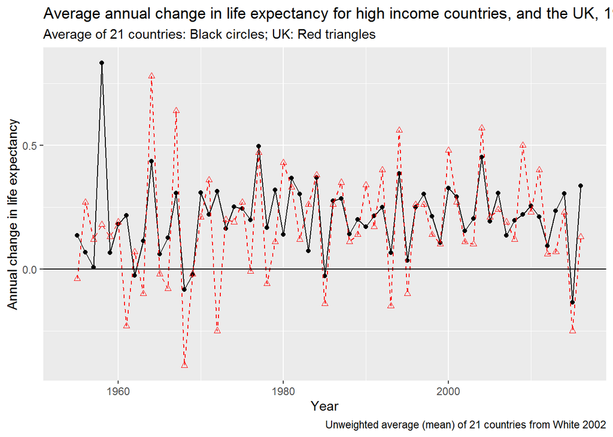

```r
tmp <- dta_e0 %>%
  filter(sex == "total") %>%
  filter(code %in% high_income_countries) %>%
  filter(between(year, 1954, 2016)) %>%
  group_by(year) %>%
  summarise(mean_e0 = mean(e0, na.rm = T)) %>%
  ungroup() %>%
  arrange(year) %>%
  mutate(ch_e0 = mean_e0 - lag(mean_e0))

tmp2 <- dta_e0 %>%
  filter(sex == "total") %>%
  filter(between(year, 1954, 2016)) %>%
  filter(code == "GBR_NP") %>%
  mutate(ch_e0 = e0 - lag(e0))

tmp %>%
  ggplot(aes(x = year, y = ch_e0)) +
  geom_point() + geom_line() +
  geom_point(
    aes(x = year, y = ch_e0),
    colour = "red", shape = 2,
    data = tmp2,
    inherit.aes = F
  ) +
  geom_line(
    aes(x = year, y = ch_e0),
    colour = "red", linetype = "dashed",
    data = tmp2,
    inherit.aes = F
  ) +
  geom_hline(yintercept = 0) +
  labs(
    title = "Average annual change in life expectancy for high income countries, and the UK, 1955-2016",
    subtitle = "Average of 21 countries: Black circles; UK: Red triangles",
    x = "Year", y = "Annual change in life expectancy",
    caption = "Unweighted average (mean) of 21 countries from White 2002"
  )
```

```r
ggsave("figures/supp_avg_ch_e0_cf_uk.png", height = 12, width = 29, units = "cm", dpi = 300)
```

UK, no bars

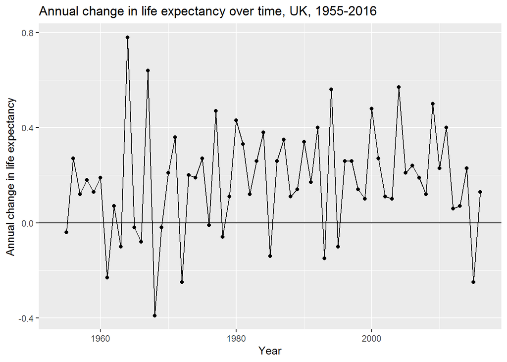

```r
tmp <- dta_e0 %>%
  filter(sex == "total") %>%
  filter(code %in% "GBR_NP") %>%
  filter(between(year, 1954, 2016)) %>%
  group_by(year) %>%
  summarise(mean_e0 = mean(e0, na.rm = T)) %>%
  ungroup() %>%
  arrange(year) %>%
  mutate(ch_e0 = mean_e0 - lag(mean_e0))

tmp %>%
  ggplot(aes(x = year, y = ch_e0)) +
  geom_point() + geom_line() +


  geom_hline(yintercept = 0) +
  labs(x = "Year", y = "Annual change in life expectancy",
       title = "Annual change in life expectancy over time, UK, 1955-2016")
```

```r
ggsave("figures/supp_uk_ch_e0.png", height = 12, width = 29, units = "cm", dpi = 300)
```

Bars for UK

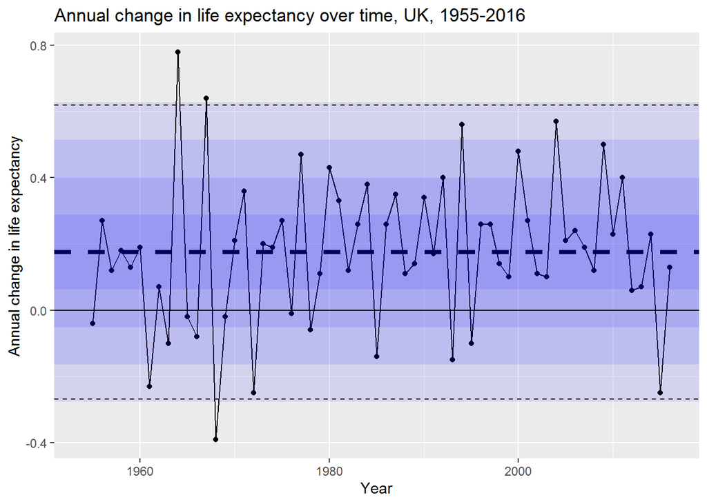

```r
tmp <- dta_e0 %>%
  filter(sex == "total") %>%
  filter(code %in% "GBR_NP") %>%
  filter(between(year, 1954, 2016)) %>%
  group_by(year) %>%
  summarise(mean_e0 = mean(e0, na.rm = T)) %>%
  ungroup() %>%
  arrange(year) %>%
  mutate(ch_e0 = mean_e0 - lag(mean_e0))

tmp %>%
  ggplot(aes(x = year, y = ch_e0)) +
  geom_point() + geom_line() +
  geom_hline(aes(yintercept = mean(ch_e0, na.rm = TRUE)), size = 1.5, linetype = "dashed") +
  annotate(geom = "rect",
      xmin = -Inf, xmax = Inf,
      ymin = mean(tmp$ch_e0, na.rm = TRUE) - 0.5 * sd(tmp$ch_e0, na.rm = TRUE),
      ymax = mean(tmp$ch_e0, na.rm = TRUE) + 0.5 * sd(tmp$ch_e0, na.rm = TRUE),
    alpha = 0.1, fill = "blue"
  ) +
  annotate(geom = "rect",
      xmin = -Inf, xmax = Inf,
      ymin = mean(tmp$ch_e0, na.rm = TRUE) - 1.0 * sd(tmp$ch_e0, na.rm = TRUE),
      ymax = mean(tmp$ch_e0, na.rm = TRUE) + 1.0 * sd(tmp$ch_e0, na.rm = TRUE),
    alpha = 0.1, fill = "blue"
  ) +
  annotate(geom = "rect",
      xmin = -Inf, xmax = Inf,
      ymin = mean(tmp$ch_e0, na.rm = TRUE) - 1.5 * sd(tmp$ch_e0, na.rm = TRUE),
      ymax = mean(tmp$ch_e0, na.rm = TRUE) + 1.5 * sd(tmp$ch_e0, na.rm = TRUE),
    alpha = 0.1, fill = "blue"
  ) +
  annotate(geom = "rect",
      xmin = -Inf, xmax = Inf,
      ymin = mean(tmp$ch_e0, na.rm = TRUE) - 2.0 * sd(tmp$ch_e0, na.rm = TRUE),
      ymax = mean(tmp$ch_e0, na.rm = TRUE) + 2.0 * sd(tmp$ch_e0, na.rm = TRUE),
    alpha = 0.1, fill = "blue"
  ) +

  geom_hline(aes(yintercept = mean(ch_e0, na.rm = TRUE) - 1.96 * sd(ch_e0, na.rm = TRUE)), linetype = "dashed") +
  geom_hline(aes(yintercept = mean(ch_e0, na.rm = TRUE) + 1.96 * sd(ch_e0, na.rm = TRUE)), linetype = "dashed") +

  geom_hline(yintercept = 0) +
  labs(x = "Year", y = "Annual change in life expectancy",
       title = "Annual change in life expectancy over time, UK, 1955-2016")
```

```r
ggsave("figures/supp_uk_ch_e0_bars.png", height = 12, width = 29, units = "cm", dpi = 300)
```

And the USA

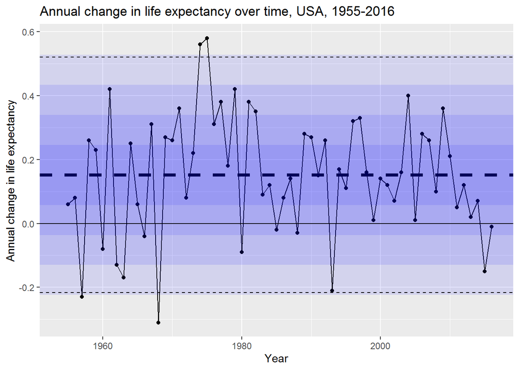

```r
tmp <- dta_e0 %>%
  filter(sex == "total") %>%
  filter(code %in% "USA") %>%
  filter(between(year, 1954, 2016)) %>%
  group_by(year) %>%
  summarise(mean_e0 = mean(e0, na.rm = T)) %>%
  ungroup() %>%
  arrange(year) %>%
  mutate(ch_e0 = mean_e0 - lag(mean_e0))

tmp %>%
  ggplot(aes(x = year, y = ch_e0)) +
  geom_point() + geom_line() +
  geom_hline(aes(yintercept = mean(ch_e0, na.rm = TRUE)), size = 1.5, linetype = "dashed") +
  annotate(geom = "rect",
      xmin = -Inf, xmax = Inf,
      ymin = mean(tmp$ch_e0, na.rm = TRUE) - 0.5 * sd(tmp$ch_e0, na.rm = TRUE),
      ymax = mean(tmp$ch_e0, na.rm = TRUE) + 0.5 * sd(tmp$ch_e0, na.rm = TRUE),
    alpha = 0.1, fill = "blue"
  ) +
  annotate(geom = "rect",
      xmin = -Inf, xmax = Inf,
      ymin = mean(tmp$ch_e0, na.rm = TRUE) - 1.0 * sd(tmp$ch_e0, na.rm = TRUE),
      ymax = mean(tmp$ch_e0, na.rm = TRUE) + 1.0 * sd(tmp$ch_e0, na.rm = TRUE),
    alpha = 0.1, fill = "blue"
  ) +
  annotate(geom = "rect",
      xmin = -Inf, xmax = Inf,
      ymin = mean(tmp$ch_e0, na.rm = TRUE) - 1.5 * sd(tmp$ch_e0, na.rm = TRUE),
      ymax = mean(tmp$ch_e0, na.rm = TRUE) + 1.5 * sd(tmp$ch_e0, na.rm = TRUE),
    alpha = 0.1, fill = "blue"
  ) +
  annotate(geom = "rect",
      xmin = -Inf, xmax = Inf,
      ymin = mean(tmp$ch_e0, na.rm = TRUE) - 2.0 * sd(tmp$ch_e0, na.rm = TRUE),
      ymax = mean(tmp$ch_e0, na.rm = TRUE) + 2.0 * sd(tmp$ch_e0, na.rm = TRUE),
    alpha = 0.1, fill = "blue"
  ) +

  geom_hline(aes(yintercept = mean(ch_e0, na.rm = TRUE) - 1.96 * sd(ch_e0, na.rm = TRUE)), linetype = "dashed") +
  geom_hline(aes(yintercept = mean(ch_e0, na.rm = TRUE) + 1.96 * sd(ch_e0, na.rm = TRUE)), linetype = "dashed") +

  geom_hline(yintercept = 0) +
  labs(x = "Year", y = "Annual change in life expectancy",
       title = "Annual change in life expectancy over time, USA, 1955-2016")
```

```r
ggsave("figures/supp_usa_ch_e0_bars.png", height = 12, width = 29, units = "cm", dpi = 300)
```

And now what about Scotland?

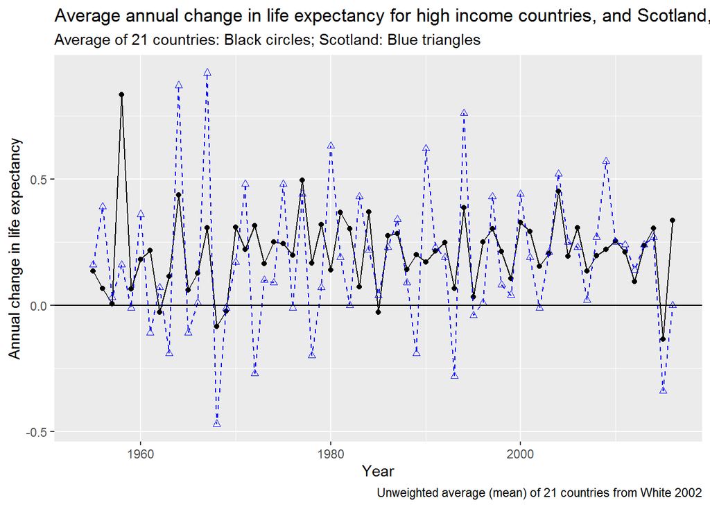

```r
tmp <- dta_e0 %>%
  filter(sex == "total") %>%
  filter(code %in% high_income_countries) %>%
  filter(between(year, 1954, 2016)) %>%
  group_by(year) %>%
  summarise(mean_e0 = mean(e0, na.rm = T)) %>%
  ungroup() %>%
  arrange(year) %>%
  mutate(ch_e0 = mean_e0 - lag(mean_e0))

tmp2 <- dta_e0 %>%
  filter(sex == "total") %>%
  filter(between(year, 1954, 2016)) %>%
  filter(code == "GBR_SCO") %>%
  mutate(ch_e0 = e0 - lag(e0))

tmp %>%
  ggplot(aes(x = year, y = ch_e0)) +
  geom_point() + geom_line() +
  geom_point(
    aes(x = year, y = ch_e0),
    colour = "blue", shape = 2,
    data = tmp2,
    inherit.aes = F
  ) +
  geom_line(
    aes(x = year, y = ch_e0),
    colour = "blue", linetype = "dashed",
    data = tmp2,
    inherit.aes = F
  ) +
  geom_hline(yintercept = 0) +
    labs(
    title = "Average annual change in life expectancy for high income countries, and Scotland, 1955-2016",
    subtitle = "Average of 21 countries: Black circles; Scotland: Blue triangles",
    x = "Year", y = "Annual change in life expectancy",
    caption = "Unweighted average (mean) of 21 countries from White 2002"
  )
```

```r
ggsave("figures/supp_avg_ch_e0_cf_scot.png", height = 12, width = 29, units = "cm", dpi = 300)
```

How about Japan and the USA?

```r
tmp <- dta_e0 %>%
  filter(sex == "total") %>%
  filter(code %in% high_income_countries) %>%
  filter(between(year, 1954, 2016)) %>%
  group_by(year) %>%
  summarise(mean_e0 = mean(e0, na.rm = T)) %>%
  ungroup() %>%
  arrange(year) %>%
  mutate(Average = mean_e0 - lag(mean_e0))

tmp2 <- dta_e0 %>%
  filter(sex == "total") %>%
  filter(between(year, 1954, 2016)) %>%
  filter(code == "JPN") %>%
  mutate(Japan = e0 - lag(e0))

tmp3 <- dta_e0 %>%
  filter(sex == "total") %>%
  filter(between(year, 1954, 2016)) %>%
  filter(code == "USA") %>%
  mutate(USA = e0 - lag(e0))

tmp4 <- tmp %>% select(year, Average) %>%
  left_join(tmp2 %>% select(year, Japan)) %>%
  left_join(tmp3 %>% select(year, USA)) %>%
  gather(key = "population", value = "ch_e0", Average:USA)
```

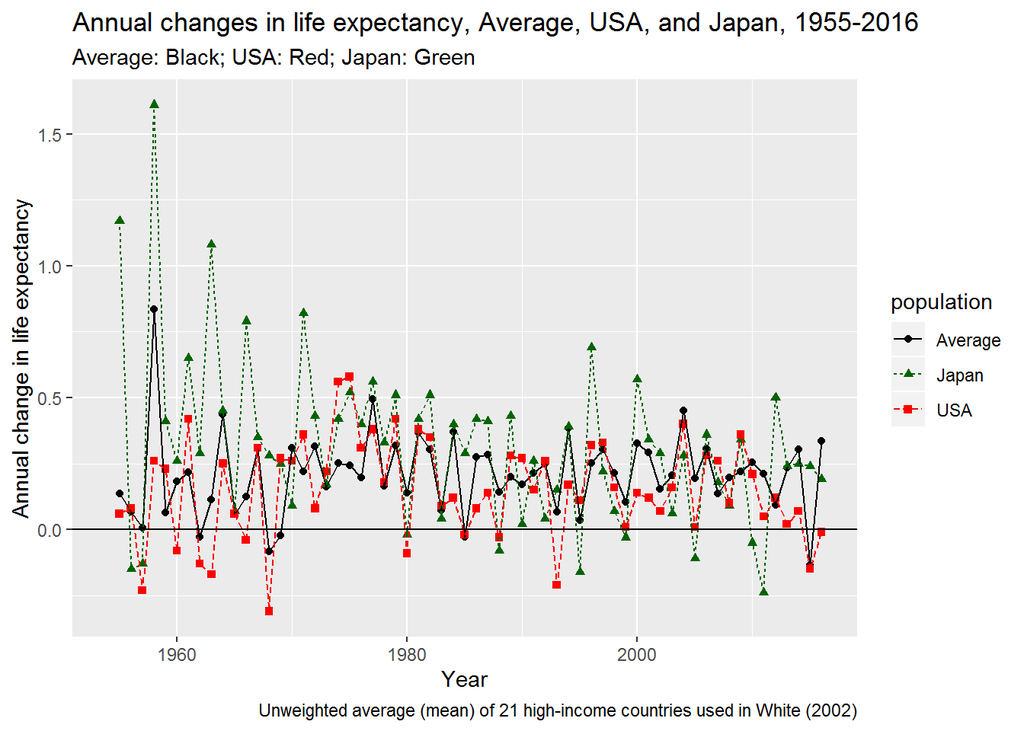

```r
tmp4 %>%
  ggplot(aes(x = year, y = ch_e0, group = population, colour = population, linetype = population, shape = population)) +
  geom_point() + geom_line() +
  geom_hline(yintercept = 0) +
  labs(
    x = "Year", y = "Annual change in life expectancy",
    title  = "Annual changes in life expectancy, Average, USA, and Japan, 1955-2016",
    subtitle = "Average: Black; USA: Red; Japan: Green",
    caption = "Unweighted average (mean) of 21 high-income countries used in White (2002)"
  ) +
  scale_colour_manual(values = c("black", "darkgreen", "red"))
```

The departure in the form the average is very clear in this figure, with the annual changes in the USA declining after 2008, and not improving at the average rate in the early 2000s either. Since the 1980s the USA appears to slow down worse than the average in the down-turns, then not recover as quickly as the average in the up-turns!

And the following does this for each of the countries

```r
tmp <- dta_e0 %>%
  filter(sex == "total") %>%
  mutate(code %in% high_income_countries) %>%
  filter(between(year, 1954, 2016)) %>%
  group_by(year) %>%
  summarise(mean_e0 = mean(e0, na.rm = T)) %>%
  ungroup() %>%
  arrange(year) %>%
  mutate(mean_ch_e0 = mean_e0 - lag(mean_e0)) %>%
  select(year, mean_ch_e0)

tmp2 <- dta_e0 %>%
  filter(sex == "total") %>%
  filter(code %in% high_income_countries) %>%
  filter(between(year, 1954, 2016)) %>%
  group_by(code) %>%
  arrange(year) %>%
  mutate(ch_e0 = e0 - lag(e0)) %>%
  ungroup() %>%
  select(year, code, ch_e0)

tmp3 <- left_join(tmp2, tmp, by = c("year" = "year"))

tmp3
```

| year | code | ch_e0 | mean_ch_e0 |
| --- | --- | --- | --- |
| 1954 | AUS | NA | NA |
| 1954 | AUT | NA | NA |
| 1954 | BEL | NA | NA |
| 1954 | CAN | NA | NA |
| 1954 | CHE | NA | NA |
| 1954 | DNK | NA | NA |
| 1954 | ESP | NA | NA |
| 1954 | FIN | NA | NA |
| 1954 | FRATNP | NA | NA |
| 1954 | IRL | NA | NA |

[output cut: 1269 more lines]

[figure not shown]

```r
tmp3 %>%
  ggplot(aes(x = year)) +
  geom_point(aes(y = mean_ch_e0), colour = "grey", alpha = 0.5) +
  geom_line(aes(y = mean_ch_e0), colour = "grey", alpha = 0.5) +
  geom_point(aes(y = ch_e0)) + geom_line(aes(y = ch_e0)) +
  facet_wrap(~code) +
  geom_hline(yintercept = 0) +
  labs(
    x = "Year",
    y = "Annual change in life expectancy",
    title = "Annual change in life expectancy for 21 high income countries compared with average",
    subtitle = "Black: Country labelled in facet. Grey: Average of 21 countries",
    caption = "Unweighted average of 21 countries used in White (2002)"
  )
```

## Figure 3

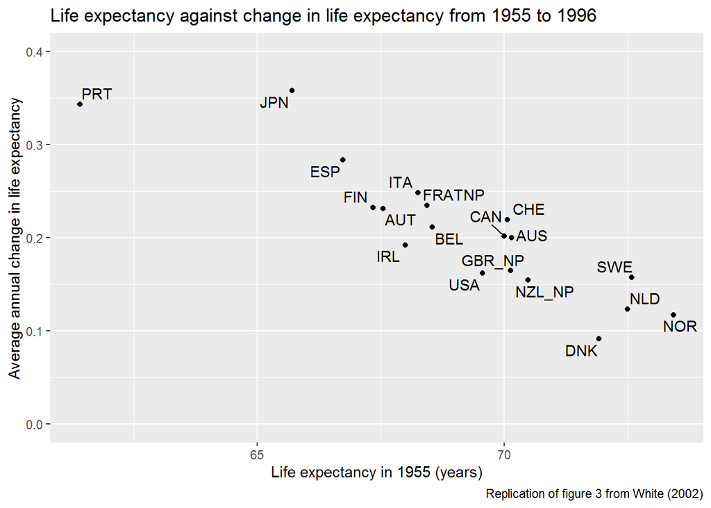

```r
dta_for_fig03 <- dta_e0 %>%
  filter(code %in% high_income_countries) %>%
  filter(sex == "total") %>%
  filter(between(year, 1955, 1996)) %>%
  group_by(code) %>%
  arrange(year) %>%
  mutate(val_in_1955 = ifelse(1955 %in% year, e0[year == 1955], NA)) %>%
  mutate(ch_e0 = e0 - lag(e0)) %>%
  mutate(mean_ch_e0 = mean(ch_e0, na.rm = T)) %>%
  filter(year == min(year)) %>%
  ungroup() %>%
  select(code, val_in_1955, mean_ch_e0)

fig03 <- dta_for_fig03 %>%
  ggplot(aes(x = val_in_1955, y = mean_ch_e0)) +
  geom_point() +
  scale_y_continuous(limits = c(0, 0.4)) +
  ggrepel::geom_text_repel(aes(label = code)) +
  labs(
    title = "Life expectancy against change in life expectancy from 1955 to 1996",
    x = "Life expectancy in 1955 (years)",
    y = "Average annual change in life expectancy",
    caption = "Replication of figure 3 from White (2002)"
    )

print(fig03)
```

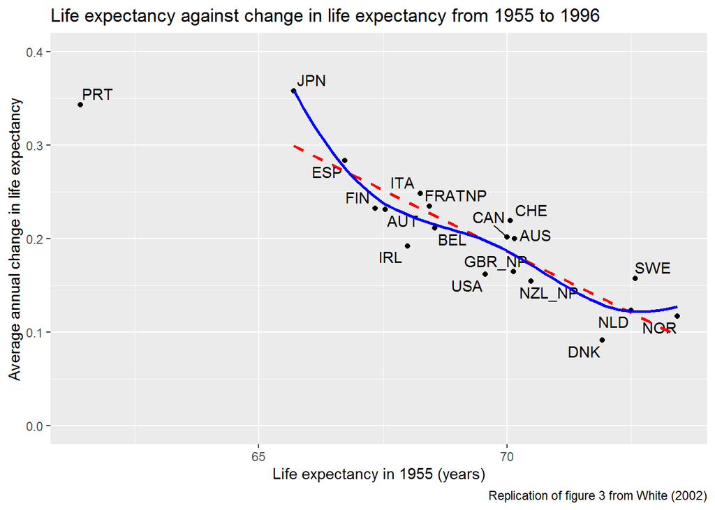

```r
ggsave("figures/pt2_white_orig.png", height = 12, width = 20, units = "cm", dpi = 300)
ggsave("figures/e0_limits/fig_2_a_change_start_1996.png", height =12, width =20, units = "cm", dpi = 300)
fig03 +
  stat_smooth(method = "lm", se = F, colour = "red", linetype = "dashed",
              data = dta_for_fig03 %>% filter(code != "PRT")) +
  geom_smooth(se = F, colour = "blue",
              data = dta_for_fig03 %>% filter(code != "PRT"))
```

```r
ggsave("figures/pt2_white_orig_smoother.png", height = 12, width = 20, units = "cm", dpi = 300)
ggsave("figures/e0_limits/appendix/fig_2_a_change_start_1996_smoother.png", height =12, width =20, units = "cm", dpi = 300)
```

What about for all HMD countries?

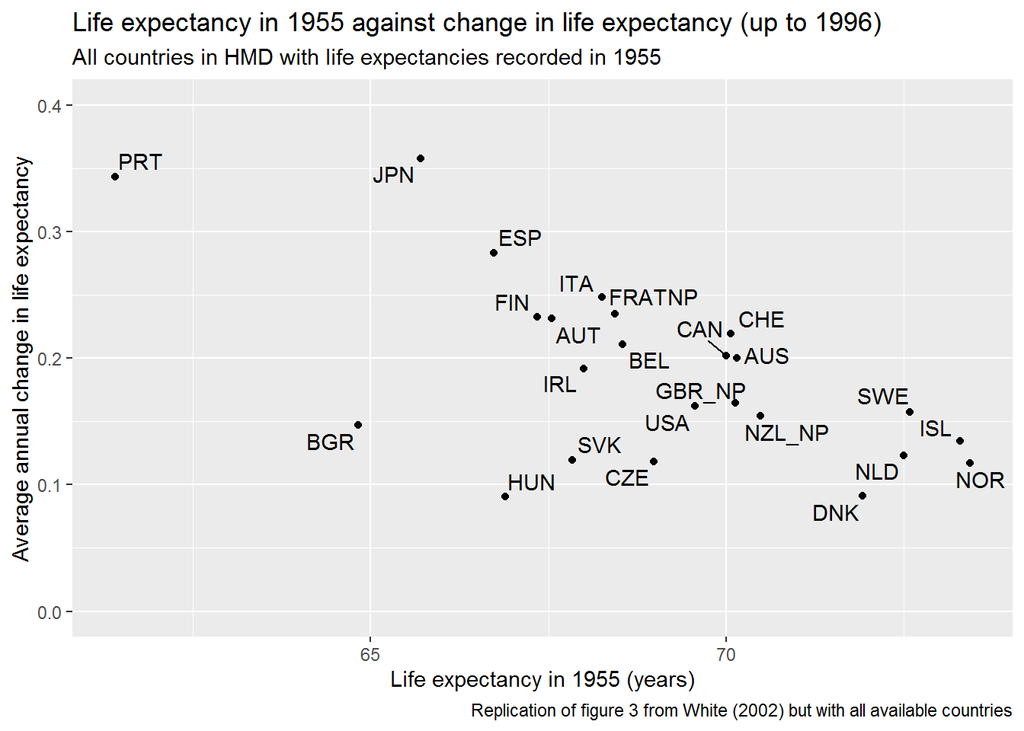

```r
fig <- dta_e0 %>%
  filter(code %in% all_distinct_countries) %>%
  filter(sex == "total") %>%
  filter(between(year, 1955, 1996)) %>%
  group_by(code) %>%
  arrange(year) %>%
  mutate(val_in_1955 = ifelse(1955 %in% year, e0[year == 1955], NA)) %>%
  mutate(ch_e0 = e0 - lag(e0)) %>%
  mutate(mean_ch_e0 = mean(ch_e0, na.rm = T)) %>%
  filter(year == min(year)) %>%
  ungroup() %>%
  select(code, val_in_1955, mean_ch_e0) %>%
  ggplot(aes(x = val_in_1955, y = mean_ch_e0)) +
  geom_point() +
  scale_y_continuous(limits = c(0, 0.4)) +
  ggrepel::geom_text_repel(aes(label = code)) +
  labs(
    title = "Life expectancy in 1955 against change in life expectancy (up to 1996)",
    subtitle = "All countries in HMD with life expectancies recorded in 1955",
    x = "Life expectancy in 1955 (years)",
    y = "Average annual change in life expectancy",
    caption = "Replication of figure 3 from White (2002) but with all available countries"
    )

print(fig)
```

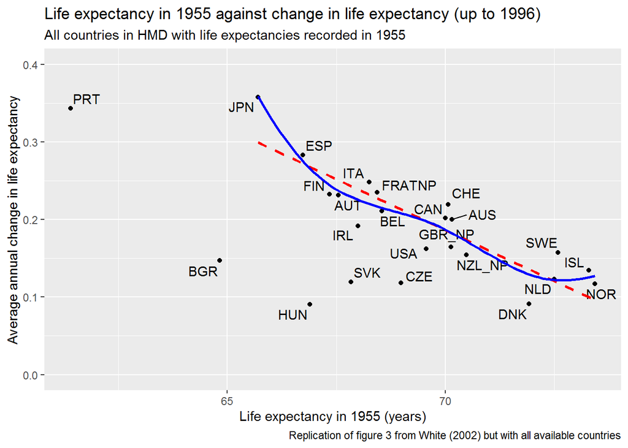

```r
ggsave("figures/e0_limits/appendix/fig_2_a_change_start_1996_allhmd.png", height =12, width =20, units = "cm", dpi = 300)
fig +
  stat_smooth(method = "lm", se = F, colour = "red", linetype = "dashed",
              data = dta_for_fig03 %>% filter(code != "PRT")) +
  geom_smooth(se = F, colour = "blue",
              data = dta_for_fig03 %>% filter(code != "PRT"))
```

```r
ggsave("figures/e0_limits/appendix/fig_2_a_change_start_1996_allhmd_smoother.png", height =12, width =20, units = "cm", dpi = 300)
```

And what about more recently?

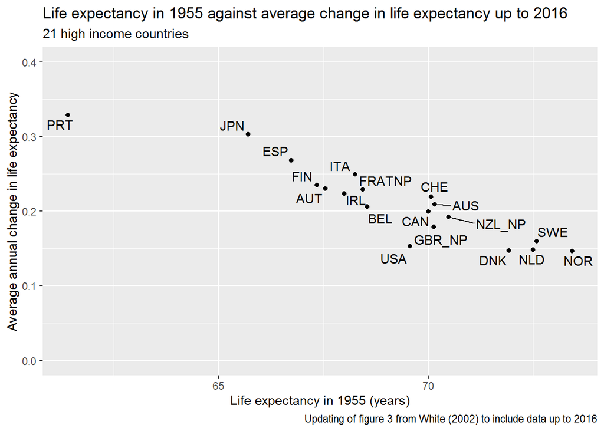

```r
tmp <- dta_e0 %>%
  filter(code %in% high_income_countries) %>%
  filter(sex == "total") %>%
  filter(between(year, 1955, 2016)) %>%
  group_by(code) %>%
  arrange(year) %>%
  mutate(val_in_1955 = ifelse(1955 %in% year, e0[year == 1955], NA)) %>%
  mutate(ch_e0 = e0 - lag(e0)) %>%
  mutate(mean_ch_e0 = mean(ch_e0, na.rm = T)) %>%
  filter(year == min(year)) %>%
  ungroup() %>%
  select(code, val_in_1955, mean_ch_e0)

fig03_update <- tmp %>%
  ggplot(aes(x = val_in_1955, y = mean_ch_e0)) +
  geom_point() +
  scale_y_continuous(limits = c(0, 0.4)) +
  ggrepel::geom_text_repel(aes(label = code)) +
  labs(
    title = "Life expectancy in 1955 against average change in life expectancy up to 2016",
    subtitle = "21 high income countries",
    x = "Life expectancy in 1955 (years)", y = "Average annual change in life expectancy",
    caption = "Updating of figure 3 from White (2002) to include data up to 2016"
    )

print(fig03_update)
```

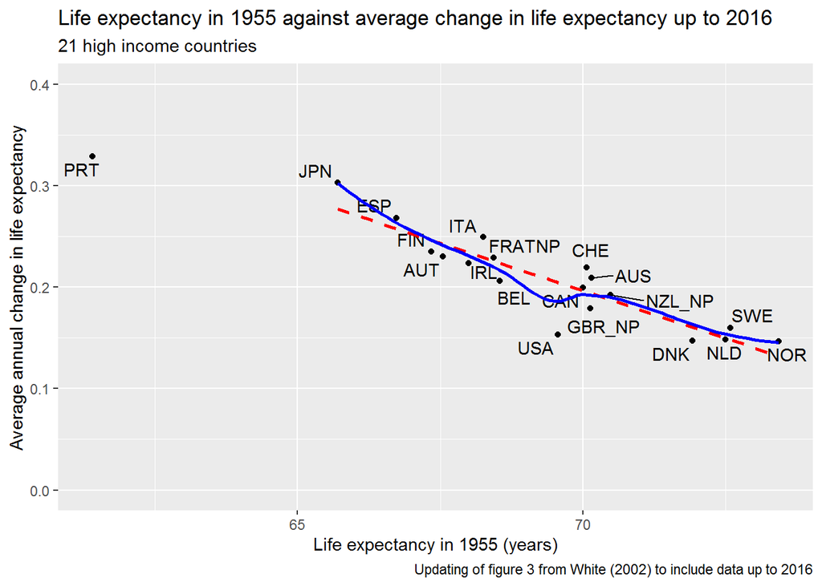

```r
ggsave("figures/pt2_white_update.png", height = 12, width = 20, units = "cm", dpi = 300)
ggsave("figures/e0_limits/fig2b_start_change_2016.png", height = 12, width = 20, units = "cm", dpi = 300)
fig03_update +
  stat_smooth(method = "lm", se = F, colour = "red", linetype = "dashed", data = tmp %>% filter(code != "PRT")) +
  geom_smooth(se = F, colour = "blue", data = tmp %>% filter(code != "PRT"))
```

```r
ggsave("figures/pt2_white_update_smoother.png", height = 12, width = 20, units = "cm", dpi = 300)
ggsave("figures/e0_limits/appendix/fig2b_start_change_2016.png", height = 12, width = 20, units = "cm", dpi = 300)
```

The important feature to note here is that, though the negative association is still apparent, it appears to have a ‘floor’ value of around 0.15, i.e. there are still continued improvements even in countries that had higher life expectancies in 1955 (such as Sweden, Denmark, the Netherlands and Norway.)

How about since 2010 only?

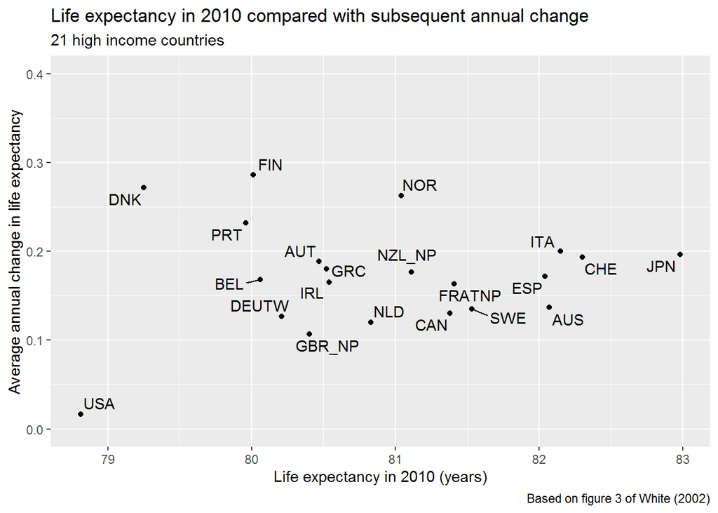

```r
tmp <- dta_e0 %>%
  filter(code %in% high_income_countries) %>%
  filter(sex == "total") %>%
  filter(between(year, 2010, 2016)) %>%
  group_by(code) %>%
  arrange(year) %>%
  mutate(val_in_2010 = ifelse(2010 %in% year, e0[year == 2010], NA)) %>%
  mutate(ch_e0 = e0 - lag(e0)) %>%
  mutate(mean_ch_e0 = mean(ch_e0, na.rm = T)) %>%
  filter(year == min(year)) %>%
  ungroup() %>%
  select(code, val_in_2010, mean_ch_e0)

tmp %>%
  ggplot(aes(x = val_in_2010, y = mean_ch_e0)) +
  geom_point() +
  scale_y_continuous(limits = c(0, 0.4)) +
  ggrepel::geom_text_repel(aes(label = code)) +
  labs(
    title = "Life expectancy in 2010 compared with subsequent annual change",
    subtitle = "21 high income countries",
    caption = "Based on figure 3 of White (2002)",
    x = "Life expectancy in 2010 (years)", y = "Average annual change in life expectancy"
    )
```

```r
ggsave("figures/pt1_supp_white_2010plus.png", height = 12, width = 20, units = "cm", dpi = 300)

ggsave("figures/e0_limits/appendix/ch_since_2010.png", height = 12, width = 20, units = "cm", dpi = 300)
```

This is an important ‘dog that didn’t bark’: there’s no apparent association between the rate of slowdown since 2010 and the life expectancy in 2010. Though the long-term tendency may be for there to be a slowdown, it’s not something that explains what happened this time.

Requestion addition: change from 1997 to 2016

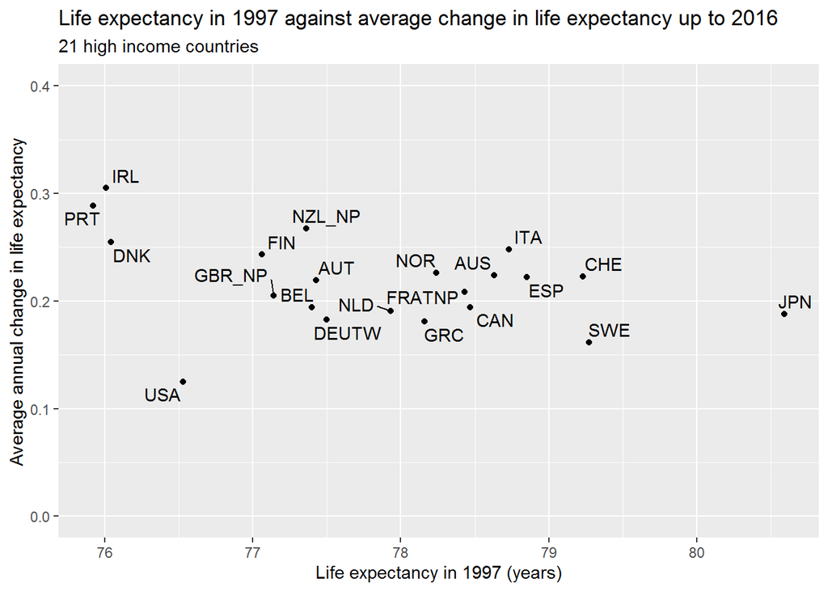

```r
tmp <- dta_e0 %>%
  filter(code %in% high_income_countries) %>%
  filter(sex == "total") %>%
  filter(between(year, 1997, 2016)) %>%
  group_by(code) %>%
  arrange(year) %>%
  mutate(val_in_1997 = ifelse(1997 %in% year, e0[year == 1997], NA)) %>%
  mutate(ch_e0 = e0 - lag(e0)) %>%
  mutate(mean_ch_e0 = mean(ch_e0, na.rm = T)) %>%
  filter(year == min(year)) %>%
  ungroup() %>%
  select(code, val_in_1997, mean_ch_e0)

fig03_update_b <- tmp %>%
  ggplot(aes(x = val_in_1997, y = mean_ch_e0)) +
  geom_point() +
  scale_y_continuous(limits = c(0, 0.4)) +
  ggrepel::geom_text_repel(aes(label = code)) +
  labs(
    title = "Life expectancy in 1997 against average change in life expectancy up to 2016",
    subtitle = "21 high income countries",
    x = "Life expectancy in 1997 (years)", y = "Average annual change in life expectancy"
    )

print(fig03_update_b)
```

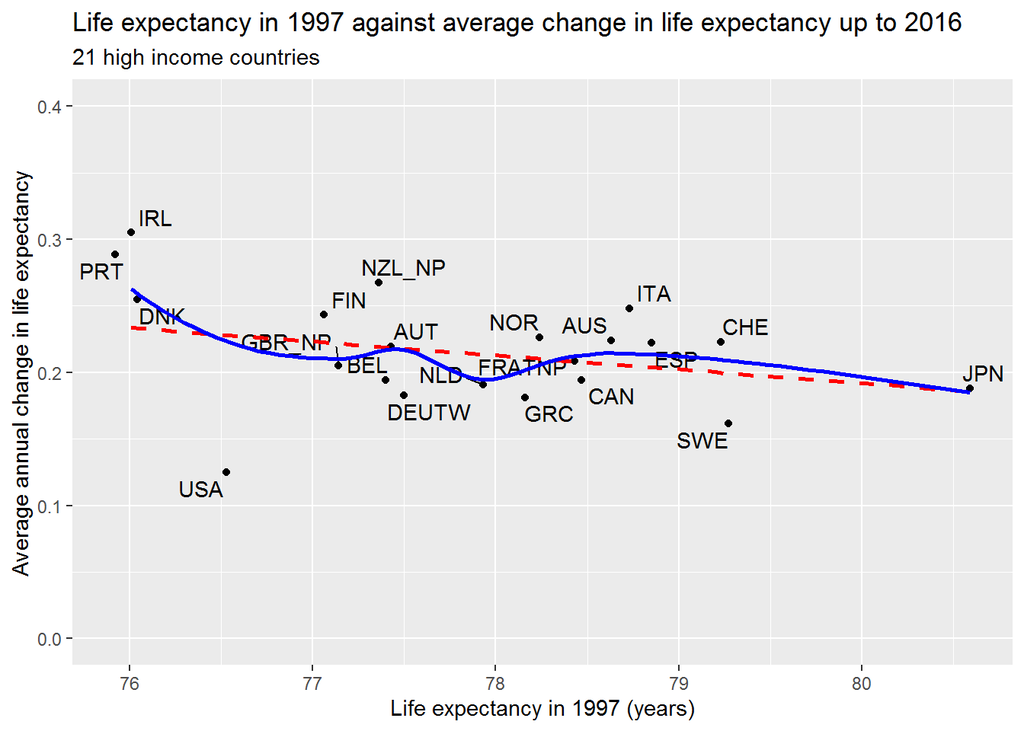

```r
ggsave("figures/pt2_white_update_b.png", height = 12, width = 20, units = "cm", dpi = 300)
ggsave("figures/e0_limits/fig2b_start_change_2016_b.png", height = 12, width = 20, units = "cm", dpi = 300)

fig03_update_b +
  stat_smooth(method = "lm", se = F, colour = "red", linetype = "dashed", data = tmp %>% filter(code != "PRT")) +
  geom_smooth(se = F, colour = "blue", data = tmp %>% filter(code != "PRT"))
```

```r
ggsave("figures/pt2_white_update_smoother_b.png", height = 12, width = 20, units = "cm", dpi = 300)
ggsave("figures/e0_limits/appendix/fig2b_start_change_2016_b.png", height = 12, width = 20, units = "cm", dpi = 300)
```

Now all countries, up to 2016

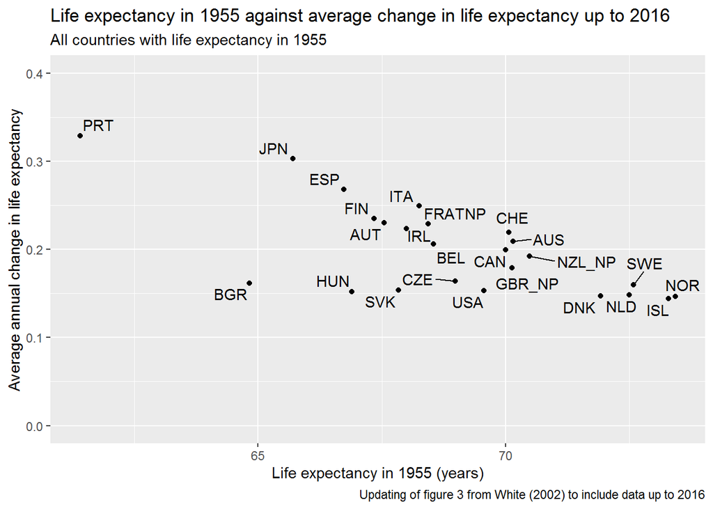

```r
tmp <- dta_e0 %>%
  filter(code %in% all_distinct_countries) %>%
  filter(sex == "total") %>%
  filter(between(year, 1955, 2016)) %>%
  group_by(code) %>%
  arrange(year) %>%
  mutate(val_in_1955 = ifelse(1955 %in% year, e0[year == 1955], NA)) %>%
  mutate(ch_e0 = e0 - lag(e0)) %>%
  mutate(mean_ch_e0 = mean(ch_e0, na.rm = T)) %>%
  filter(year == min(year)) %>%
  ungroup() %>%
  select(code, val_in_1955, mean_ch_e0)

fig03_update <- tmp %>%
  ggplot(aes(x = val_in_1955, y = mean_ch_e0)) +
  geom_point() +
  scale_y_continuous(limits = c(0, 0.4)) +
  ggrepel::geom_text_repel(aes(label = code)) +
  labs(
    title = "Life expectancy in 1955 against average change in life expectancy up to 2016",
    subtitle = "All countries with life expectancy in 1955",
    x = "Life expectancy in 1955 (years)", y = "Average annual change in life expectancy",
    caption = "Updating of figure 3 from White (2002) to include data up to 2016"
    )

print(fig03_update)
```

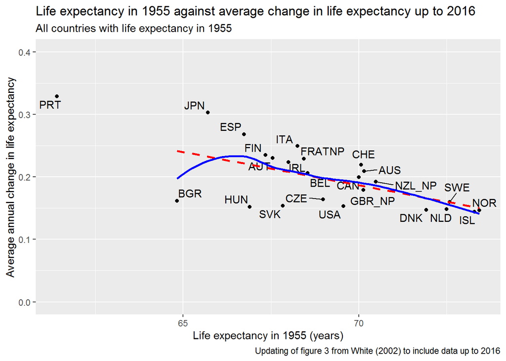

```r
ggsave("figures/e0_limits/appendix/fig2b_start_change_2016_allhmd.png", height = 12, width = 20, units = "cm", dpi = 300)
fig03_update +
  stat_smooth(method = "lm", se = F, colour = "red", linetype = "dashed", data = tmp %>% filter(code != "PRT")) +
  geom_smooth(se = F, colour = "blue", data = tmp %>% filter(code != "PRT"))
```

```r
ggsave("figures/e0_limits/appendix/fig2b_start_change_2016_allhmd_smoother.png", height = 12, width = 20, units = "cm", dpi = 300)
```

Let’s see if this were the case for other ten year periods

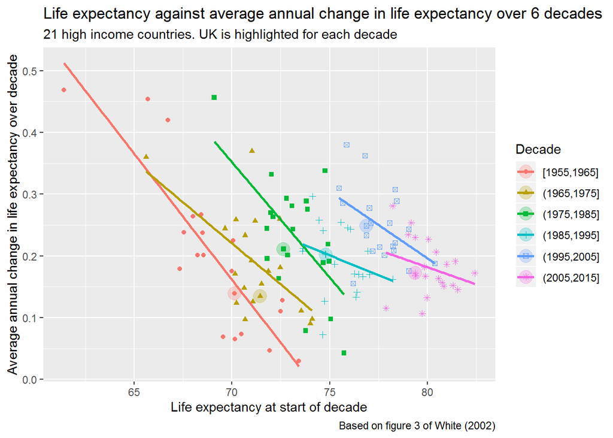

```r
tmp <- dta_e0 %>%
  filter(code %in% high_income_countries) %>%
  filter(sex == "total") %>%
  filter(between(year, 1955, 2015)) %>%
  mutate(Decade = cut(year, seq(1955, 2015, by = 10), include.lowest = T)) %>%
  group_by(code, Decade) %>%
  arrange(year) %>%
  mutate(ch_e0 = e0 - lag(e0)) %>%
  mutate(mean_ch_e0 = mean(ch_e0, na.rm = T)) %>%
  filter(year == min(year))

tmp2 <- tmp %>% filter(code == "GBR_NP")

tmp %>%
  ggplot(
    aes(x = e0, y = mean_ch_e0, group = Decade, colour = Decade, shape = Decade)
    ) +
  geom_point() +
  geom_point(
    aes(x = e0, y = mean_ch_e0, group = Decade, colour = Decade, shape = Decade),
    inherit.aes = FALSE,
    data = tmp2,
    shape = 19, size = 5, alpha = 0.25
  ) +
  stat_smooth(method = "lm", se = F) +
  labs(
    title = "Life expectancy against average annual change in life expectancy over 6 decades",
    subtitle = "21 high income countries. UK is highlighted for each decade",
    x = "Life expectancy at start of decade",
    y = "Average annual change in life expectancy over decade",
    caption = "Based on figure 3 of White (2002)"
  )
```

```r
ggsave("figures/pt1_white_sliced.png", height = 12, width = 20, units = "cm", dpi = 300)
ggsave("figures/e0_limits/sliced_startchange.png", height = 12, width = 20, units = "cm", dpi = 300)
```

This figure shows that the degree to which the limits-to-growth argument holds in high income countries is falling, rather than increasing, again suggesting it is not an important factor in explaining the recent slowdown in the UK (highlighted with a translucent symbol).

And now, all countries

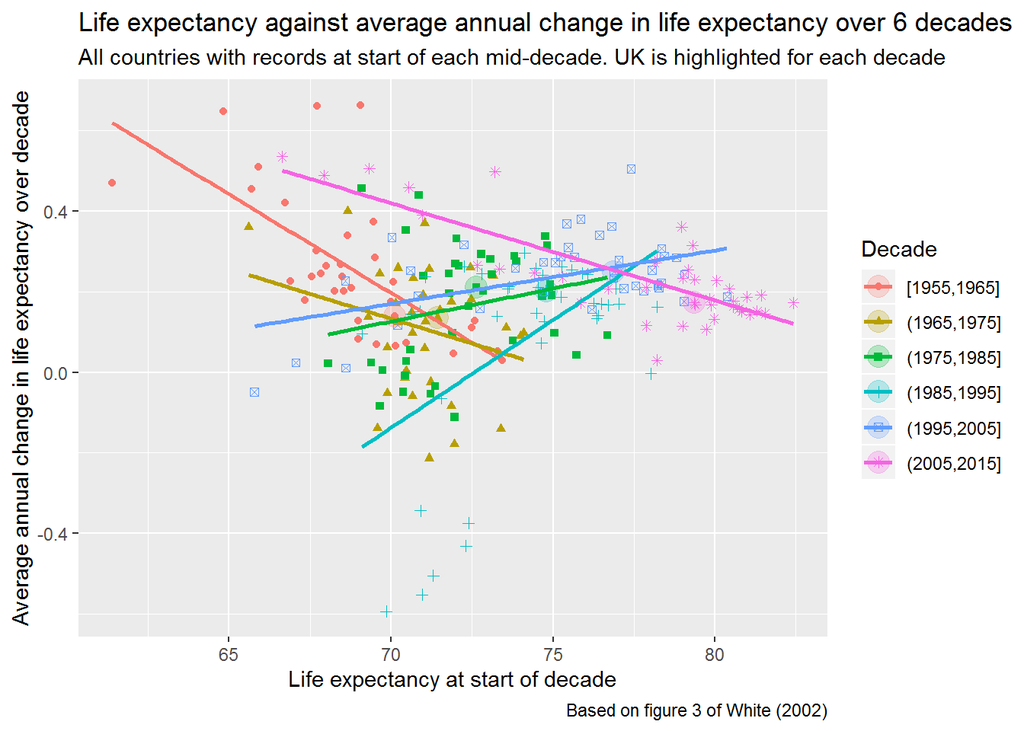

```r
tmp <- dta_e0 %>%
  filter(code %in% all_distinct_countries) %>%
  filter(sex == "total") %>%
  filter(between(year, 1955, 2015)) %>%
  mutate(Decade = cut(year, seq(1955, 2015, by = 10), include.lowest = T)) %>%
  group_by(code, Decade) %>%
  arrange(year) %>%
  mutate(ch_e0 = e0 - lag(e0)) %>%
  mutate(mean_ch_e0 = mean(ch_e0, na.rm = T)) %>%
  filter(year == min(year))

tmp2 <- tmp %>% filter(code == "GBR_NP")

tmp %>%
  ggplot(
    aes(x = e0, y = mean_ch_e0, group = Decade, colour = Decade, shape = Decade)
    ) +
  geom_point() +
  geom_point(
    aes(x = e0, y = mean_ch_e0, group = Decade, colour = Decade, shape = Decade),
    inherit.aes = FALSE,
    data = tmp2,
    shape = 19, size = 5, alpha = 0.25
  ) +
  stat_smooth(method = "lm", se = F) +
  labs(
    title = "Life expectancy against average annual change in life expectancy over 6 decades",
    subtitle = "All countries with records at start of each mid-decade. UK is highlighted for each decade",
    x = "Life expectancy at start of decade",
    y = "Average annual change in life expectancy over decade",
    caption = "Based on figure 3 of White (2002)"
  )
```

```r
ggsave("figures/e0_limits/appendix/sliced_startchange_allhmd.png", height = 12, width = 20, units = "cm", dpi = 300)
```

The changing composition of the countries means there’s no longer a clear pattern.

# Changing availability of countries over time

The following figure will show if a country is present or absent for a particular year

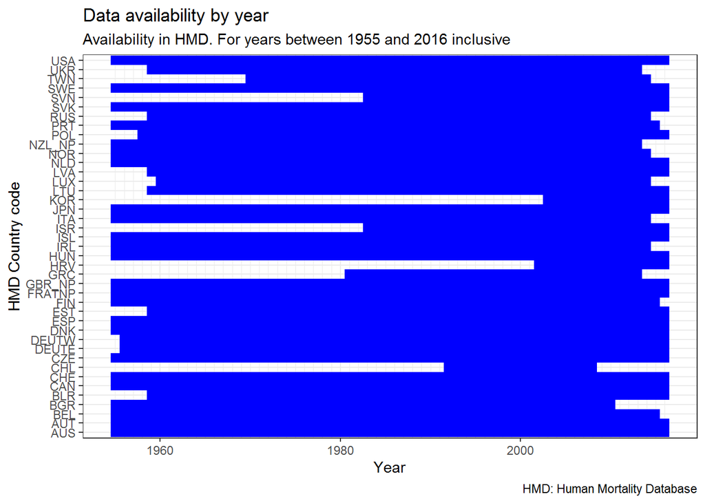

```r
dta_e0 %>%
  filter(code %in% all_distinct_countries) %>%
  filter(sex == "total") %>%
  select(-sex) %>%
  mutate(data_present = is.finite(e0)) %>%
  select(code, year, data_present) %>%
  right_join(tibble(year = 1955:2016)) %>%
  ggplot(aes(y = code, x = year, fill = data_present)) +
  geom_tile() +
  scale_fill_manual(values = c(`TRUE` = 'blue', `FALSE` = 'green')) +
  theme_bw() + theme(legend.position = 'none') +
  labs(title = "Data availability by year",
       subtitle = "Availability in HMD. For years between 1955 and 2016 inclusive", x = "Year", y = "HMD Country code",
       caption = "HMD: Human Mortality Database") +
  scale_x_continuous(minor_breaks = 1955:2016)
```

```r
ggsave("figures/e0_limits/appendix/data_availability_map.png", height = 15, width = 15, units = "cm", dpi = 300)
```